# STA141B Assignment 3

Chad Pickering

**Corresponded with:** Ricky Safran, Sierra Tevlin, Nivi Achanta, Hannah Kosinovsky, Janice Luong

**Resources used:**

- http://stackoverflow.com/questions/31593201/pandas-iloc-vs-ix-vs-loc-explanation
- http://stackoverflow.com/questions/17063458/reading-an-excel-file-in-python-using-pandas
- https://github.com/wrightaprilm/WorkshopTTU/blob/master/data-crunching/03-checking_your_data.md
- http://stackoverflow.com/questions/24037507/converting-string-objects-to-int-float-using-pandas
- http://stackoverflow.com/questions/17071871/select-rows-from-a-dataframe-based-on-values-in-a-column-in-pandas
- http://pbpython.com/excel-file-combine.html
- https://docs.python.org/2/library/stdtypes.html
- https://pythonspot.com/matplotlib-bar-chart/
- ...and a lot more.

The US Department of Agriculture publishes price estimates for fruits and vegetables [online](https://www.ers.usda.gov/data-products/fruit-and-vegetable-prices/fruit-and-vegetable-prices/). The most recent estimates are based on a 2013 survey of US retail stores.

The estimates are provided as a collection of MS Excel files, with one file per fruit or vegetable. The `assignment3_data.zip` file contains the fruit and vegetable files in the directories `fruit` and `vegetables`, respectively.

**Exercise 1.1.** Use pandas to extract the "Fresh" row(s) from the **fruit** Excel files. Combine the data into a single data frame. Your data frame should look something like this:

| type | food | form | price_per_lb | yield | lb_per_cup | price_per_cup |
| --- | --- | --- | --- | --- | --- | --- |
| fruit | watermelon | Fresh1 | 0.333412 | 0.52 | 0.330693 | 0.212033 |
| fruit | cantaloupe | Fresh1 | 0.535874 | 0.51 | 0.374786 | 0.3938 |
| vegetables | onions | Fresh1 | 1.03811 | 0.9 | 0.35274 | 0.406868 |
| ... |  |  |  |  |  |  |

It's okay if the rows and columns of your data frame are in a different order. These modules are especially relevant:

- [`str` methods](https://docs.python.org/2/library/stdtypes.html#string-methods)
- [`os`](https://docs.python.org/2/library/os.html)
- [`os.path`](https://docs.python.org/2/library/os.path.html)
- [pandas](http://pandas.pydata.org/pandas-docs/stable/): `read_excel()`, `concat()`, `.fillna()`, `.str`, plotting methods

Ask questions and search the documentation/web to find the functions you need.

```python
import pandas as pd
import os
import os.path

# Path to files
prefix = "assignment3_data/"
food_type = prefix + "fruit/" # full, will use in for loop later
files_dir = os.listdir(food_type)

# Use list comprehension to get list of .xlsx files
files = [x for x in files_dir if x.endswith("xlsx")]

# Empty df
data_df = pd.DataFrame()

# Create beginning of 2 columns for type (fruit, etc.) and product
type_product = [['type','food']]

for h in range(len(files)):
    # Iterate through paths to each fruit
    product_i = food_type + files[h]

    # Removes all cells with NaN values
    prod_remNA = pd.read_excel(product_i, header = 1).dropna()

    # Drops the columns with units
    prod_fresh = prod_remNA.drop(prod_remNA.columns[[2, 5]], axis = 1)

    # Finds desired row that begins with "Fresh"; iloc[:,0] identifies look in the first col
    prod_fresh = prod_fresh[prod_fresh.iloc[:,0].str.endswith('Fresh1')]

    # Appends new "fresh" row to the bottom of the growing df
    data_df = data_df.append(prod_fresh, ignore_index = True)[prod_fresh.columns.tolist()]

    # If df is not empty (some fruits have no "fresh" row),
    # get type (in this case fruit) and product name for the "type_product"
    if not prod_fresh.empty:
        prod_name = ['fruit', files[h][:-5]]
        type_product.append(prod_name)

# Create df with left-most columns for final df, "type" and "food"
food_df = pd.DataFrame(type_product[1:], columns = type_product[0])

# Removes all columns with any NA values if they exist
data_df = data_df.dropna(1)

# Concatenate food and data dfs column-wise
fruit_df = pd.concat([food_df, data_df], axis = 1, join='inner')

# Use dictionary-like rename function to make the column names match the example
fruit_df = fruit_df.rename(index = str,
                               columns = {"type":"type",
                                        "food":"food",
                                        "Form":"form",
                                        "Average retail price ":"price_per_lb",
                                        "Preparation":"yield",
                                        "Size of a ":"lb_per_cup",
                                        "Average price":"price_per_cup"})

fruit_df
```

|  | type | food | form | price_per_lb | yield | lb_per_cup | price_per_cup |
| --- | --- | --- | --- | --- | --- | --- | --- |
| 0 | fruit | apples | Fresh1 | 1.56752 | 0.9 | 0.242508 | 0.422373 |
| 1 | fruit | apricots | Fresh1 | 3.04007 | 0.93 | 0.363763 | 1.1891 |
| 2 | fruit | bananas | Fresh1 | 0.566983 | 0.64 | 0.330693 | 0.292965 |
| 3 | fruit | blueberries | Fresh1 | 4.73462 | 0.95 | 0.31967 | 1.59318 |
| 4 | fruit | cantaloupe | Fresh1 | 0.535874 | 0.51 | 0.374786 | 0.3938 |
| 5 | fruit | cherries | Fresh1 | 3.59299 | 0.92 | 0.341717 | 1.33455 |
| 6 | fruit | grapefruit | Fresh1 | 0.897802 | 0.49 | 0.462971 | 0.848278 |
| 7 | fruit | grapes | Fresh1 | 2.09383 | 0.96 | 0.330693 | 0.721266 |
| 8 | fruit | honeydew | Fresh1 | 0.796656 | 0.46 | 0.374786 | 0.649077 |
| 9 | fruit | kiwi | Fresh1 | 2.04468 | 0.76 | 0.385809 | 1.03797 |
| 10 | fruit | mangoes | Fresh1 | 1.37756 | 0.71 | 0.363763 | 0.705783 |
| 11 | fruit | nectarines | Fresh1 | 1.76115 | 0.91 | 0.31967 | 0.618667 |
| 12 | fruit | oranges | Fresh1 | 1.03517 | 0.73 | 0.407855 | 0.578357 |
| 13 | fruit | papaya | Fresh1 | 1.29801 | 0.62 | 0.308647 | 0.646174 |
| 14 | fruit | peaches | Fresh1 | 1.59119 | 0.96 | 0.341717 | 0.56639 |
| 15 | fruit | pears | Fresh1 | 1.46157 | 0.9 | 0.363763 | 0.59074 |
| 16 | fruit | plums | Fresh1 | 1.82742 | 0.94 | 0.363763 | 0.707176 |
| 17 | fruit | pomegranate | Fresh1 | 2.17359 | 0.56 | 0.341717 | 1.32634 |
| 18 | fruit | raspberries | Fresh1 | 6.97581 | 0.96 | 0.31967 | 2.32287 |
| 19 | fruit | strawberries | Fresh1 | 2.35881 | 0.94 | 0.31967 | 0.802171 |
| 20 | fruit | tangerines | Fresh1 | 1.37796 | 0.74 | 0.407855 | 0.759471 |
| 21 | fruit | watermelon | Fresh1 | 0.333412 | 0.52 | 0.330693 | 0.212033 |

**Note:** The fruits files "berries_mixed," "cranberries," "dates," "figs," and "fruit_cocktail" do not have a "Fresh" row, and are therefore omitted. The fruit file "pineapple" does have a "Fresh" row, but the file format is slightly incompatible with the program - it has two extra empty columns ([7] and [8]) - and is also omitted. If these files are used in a future assignment, I will work to include "pineapple" data.

**Exercise 1.2.** Reuse your code from exercise 1.1 to extract the "Fresh" row(s) from the **vegetable** Excel files.

Does your code produce the correct prices for tomatoes? If not, why not? Do any other files have the same problem as the tomatoes file?

You don't need to extract the prices for these problem files. However, make sure the prices are extracted for files like asparagus that don't have this problem.

```python
import pandas as pd
import os
import os.path

# Path to files
prefix_veg = "assignment3_data/"
food_type_veg = prefix_veg + "vegetables/" # full, will use in for loop later
files_dir_veg = os.listdir(food_type_veg)

# Use list comprehension to get list of .xlsx files
files_veg = [x for x in files_dir_veg if x.endswith("xlsx")]

# Empty df
data_df_veg = pd.DataFrame()

# Create beginning of 2 columns for type (fruit, etc.) and product
type_product_veg = [['type','food']]

for h in range(len(files_veg)):
    # Iterate through paths to each fruit
    product_i_veg = food_type_veg + files_veg[h]

    # Removes all cells with NaN values
    prod_remNA_veg = pd.read_excel(product_i_veg, header = 1).dropna()

    # Drops the columns with units
    prod_fresh_veg = prod_remNA_veg.drop(prod_remNA_veg.columns[[2, 5]], axis = 1)

    # Finds desired row that begins with "Fresh"; iloc[:,0] identifies look in the first col
    prod_fresh_veg = prod_fresh_veg[prod_fresh_veg.iloc[:,0].str.endswith('Fresh1')]

    # Appends new "fresh" row to the bottom of the growing df
    data_df_veg = data_df_veg.append(prod_fresh_veg, ignore_index = True)[prod_fresh_veg.columns.tolist()]

    # If df is not empty (some fruits have no "fresh" row),
    # get type (in this case fruit) and product name for the "type_product"
    if not prod_fresh_veg.empty:
        prod_name_veg = ['vegetables', files_veg[h][:-5]]
        type_product_veg.append(prod_name_veg)

# Create df with left-most columns for final df, "type" and "food"
food_df_veg = pd.DataFrame(type_product_veg[1:], columns = type_product_veg[0])

# Removes all columns with any NA values if they exist
data_df_veg = data_df_veg.dropna(1)

# Concatenate food and data dfs column-wise
veg_df = pd.concat([food_df_veg, data_df_veg], axis = 1, join = 'inner')

# Use dictionary-like rename function to make the column names match the example
veg_df = veg_df.rename(index = str,
                               columns = {"type":"type",
                                        "food":"food",
                                        "Form":"form",
                                        "Average retail price ":"price_per_lb",
                                        "Preparation":"yield",
                                        "Size of a ":"lb_per_cup",
                                        "Average price":"price_per_cup"})

veg_df
```

|  | type | food | form | price_per_lb | yield | lb_per_cup | price_per_cup |
| --- | --- | --- | --- | --- | --- | --- | --- |
| 0 | vegetables | acorn_squash | Fresh1 | 1.172248 | 0.458554 | 0.451948 | 1.15536 |
| 1 | vegetables | artichoke | Fresh1 | 2.213050 | 0.375309 | 0.385809 | 2.27497 |
| 2 | vegetables | asparagus | Fresh1 | 3.213494 | 0.493835 | 0.396832 | 2.58227 |
| 3 | vegetables | avocados | Fresh1 | 2.235874 | 0.740753 | 0.31967 | 0.964886 |
| 4 | vegetables | brussels_sprouts | Fresh1 | 2.763553 | 1.06 | 0.341717 | 0.890898 |
| 5 | vegetables | butternut_squash | Fresh1 | 1.244737 | 0.714 | 0.451948 | 0.787893 |
| 6 | vegetables | collard_greens | Fresh1 | 2.630838 | 1.16 | 0.286601 | 0.650001 |
| 7 | vegetables | corn_sweet | Fresh1 | 2.690623 | 0.54 | 0.363763 | 1.8125 |
| 8 | vegetables | green_beans | Fresh1 | 2.139972 | 0.846575 | 0.275578 | 0.696606 |
| 9 | vegetables | green_peppers | Fresh1 | 1.410363 | 0.82 | 0.264555 | 0.455022 |
| 10 | vegetables | kale | Fresh1 | 2.807302 | 1.05 | 0.286601 | 0.766262 |
| 11 | vegetables | lettuce_iceberg | Fresh1 | 1.213039 | 0.95 | 0.242508 | 0.309655 |
| 12 | vegetables | mustard_greens | Fresh1 | 2.569235 | 0.84 | 0.308647 | 0.944032 |
| 13 | vegetables | okra | Fresh1 | 3.213552 | 0.769474 | 0.35274 | 1.47315 |
| 14 | vegetables | onions | Fresh1 | 1.038107 | 0.9 | 0.35274 | 0.406868 |
| 15 | vegetables | potatoes | Fresh1 | 0.564320 | 0.811301 | 0.264555 | 0.184017 |
| 16 | vegetables | radish | Fresh1 | 1.311629 | 0.9 | 0.275578 | 0.401618 |
| 17 | vegetables | red_peppers | Fresh1 | 2.277940 | 0.82 | 0.264555 | 0.734926 |
| 18 | vegetables | summer_squash | Fresh1 | 1.639477 | 0.7695 | 0.396832 | 0.84548 |
| 19 | vegetables | sweet_potatoes | Fresh1 | 0.918897 | 0.811301 | 0.440925 | 0.4994 |
| 20 | vegetables | turnip_greens | Fresh1 | 2.471749 | 0.75 | 0.31967 | 1.05353 |

**Does your code produce the correct prices for tomatoes? If not, why not? Do any other files have the same problem as the tomatoes file?** Because "Fresh" is a category containing multiple kinds of tomatoes and not a single row as expected, no one price (or any price in my case) is returned. There are multiple accurate prices depending on type of tomato, so this format is not compatible here. Other files such as "broccoli," "carrots," "cauliflower," "celery," "lettuce_romaine," "mushrooms," and "spinach" have the same issue, where there are multiple kinds of the product, and therefore multiple "Fresh" prices. There are also vegetables such as "cabbage" that matched with "Fresh1" but had valid entries for a subgroup just after it in the row as usual. This created problems because as the iteration continued, the next "Fresh1" matches in "cabbage", for example, would input the data in the "collard greens" row.

**Exercise 1.3.** Remove rows without a price from the vegetable data frame and then combine the fruit and vegetable data frames. Make sure all columns of numbers are numeric (not strings).

```python
# Full data frame
fv_df = pd.concat([fruit_df, veg_df], axis = 0, join = 'inner', ignore_index = True)
fv_df
```

|  | type | food | form | price_per_lb | yield | lb_per_cup | price_per_cup |
| --- | --- | --- | --- | --- | --- | --- | --- |
| 0 | fruit | apples | Fresh1 | 1.56752 | 0.9 | 0.242508 | 0.422373 |
| 1 | fruit | apricots | Fresh1 | 3.04007 | 0.93 | 0.363763 | 1.1891 |
| 2 | fruit | bananas | Fresh1 | 0.566983 | 0.64 | 0.330693 | 0.292965 |
| 3 | fruit | blueberries | Fresh1 | 4.73462 | 0.95 | 0.31967 | 1.59318 |
| 4 | fruit | cantaloupe | Fresh1 | 0.535874 | 0.51 | 0.374786 | 0.3938 |
| 5 | fruit | cherries | Fresh1 | 3.59299 | 0.92 | 0.341717 | 1.33455 |
| 6 | fruit | grapefruit | Fresh1 | 0.897802 | 0.49 | 0.462971 | 0.848278 |
| 7 | fruit | grapes | Fresh1 | 2.09383 | 0.96 | 0.330693 | 0.721266 |
| 8 | fruit | honeydew | Fresh1 | 0.796656 | 0.46 | 0.374786 | 0.649077 |
| 9 | fruit | kiwi | Fresh1 | 2.04468 | 0.76 | 0.385809 | 1.03797 |
| 10 | fruit | mangoes | Fresh1 | 1.37756 | 0.71 | 0.363763 | 0.705783 |
| 11 | fruit | nectarines | Fresh1 | 1.76115 | 0.91 | 0.31967 | 0.618667 |
| 12 | fruit | oranges | Fresh1 | 1.03517 | 0.73 | 0.407855 | 0.578357 |
| 13 | fruit | papaya | Fresh1 | 1.29801 | 0.62 | 0.308647 | 0.646174 |
| 14 | fruit | peaches | Fresh1 | 1.59119 | 0.96 | 0.341717 | 0.56639 |
| 15 | fruit | pears | Fresh1 | 1.46157 | 0.9 | 0.363763 | 0.59074 |
| 16 | fruit | plums | Fresh1 | 1.82742 | 0.94 | 0.363763 | 0.707176 |
| 17 | fruit | pomegranate | Fresh1 | 2.17359 | 0.56 | 0.341717 | 1.32634 |
| 18 | fruit | raspberries | Fresh1 | 6.97581 | 0.96 | 0.31967 | 2.32287 |
| 19 | fruit | strawberries | Fresh1 | 2.35881 | 0.94 | 0.31967 | 0.802171 |
| 20 | fruit | tangerines | Fresh1 | 1.37796 | 0.74 | 0.407855 | 0.759471 |
| 21 | fruit | watermelon | Fresh1 | 0.333412 | 0.52 | 0.330693 | 0.212033 |
| 22 | vegetables | acorn_squash | Fresh1 | 1.17225 | 0.458554 | 0.451948 | 1.15536 |
| 23 | vegetables | artichoke | Fresh1 | 2.21305 | 0.375309 | 0.385809 | 2.27497 |
| 24 | vegetables | asparagus | Fresh1 | 3.21349 | 0.493835 | 0.396832 | 2.58227 |
| 25 | vegetables | avocados | Fresh1 | 2.23587 | 0.740753 | 0.31967 | 0.964886 |
| 26 | vegetables | brussels_sprouts | Fresh1 | 2.76355 | 1.06 | 0.341717 | 0.890898 |
| 27 | vegetables | butternut_squash | Fresh1 | 1.24474 | 0.714 | 0.451948 | 0.787893 |
| 28 | vegetables | collard_greens | Fresh1 | 2.63084 | 1.16 | 0.286601 | 0.650001 |
| 29 | vegetables | corn_sweet | Fresh1 | 2.69062 | 0.54 | 0.363763 | 1.8125 |
| 30 | vegetables | green_beans | Fresh1 | 2.13997 | 0.846575 | 0.275578 | 0.696606 |
| 31 | vegetables | green_peppers | Fresh1 | 1.41036 | 0.82 | 0.264555 | 0.455022 |
| 32 | vegetables | kale | Fresh1 | 2.8073 | 1.05 | 0.286601 | 0.766262 |
| 33 | vegetables | lettuce_iceberg | Fresh1 | 1.21304 | 0.95 | 0.242508 | 0.309655 |
| 34 | vegetables | mustard_greens | Fresh1 | 2.56924 | 0.84 | 0.308647 | 0.944032 |
| 35 | vegetables | okra | Fresh1 | 3.21355 | 0.769474 | 0.35274 | 1.47315 |
| 36 | vegetables | onions | Fresh1 | 1.03811 | 0.9 | 0.35274 | 0.406868 |
| 37 | vegetables | potatoes | Fresh1 | 0.56432 | 0.811301 | 0.264555 | 0.184017 |
| 38 | vegetables | radish | Fresh1 | 1.31163 | 0.9 | 0.275578 | 0.401618 |
| 39 | vegetables | red_peppers | Fresh1 | 2.27794 | 0.82 | 0.264555 | 0.734926 |
| 40 | vegetables | summer_squash | Fresh1 | 1.63948 | 0.7695 | 0.396832 | 0.84548 |
| 41 | vegetables | sweet_potatoes | Fresh1 | 0.918897 | 0.811301 | 0.440925 | 0.4994 |
| 42 | vegetables | turnip_greens | Fresh1 | 2.47175 | 0.75 | 0.31967 | 1.05353 |

```python
# All types are objects
print(fv_df.dtypes)
fv_df.ix[:,3]
```

```
type             object
food             object
form             object
price_per_lb     object
yield            object
lb_per_cup       object
price_per_cup    object
dtype: object
```

```
0      1.56752
1      3.04007
2     0.566983
3      4.73462
4     0.535874
5      3.59299
6     0.897802
7      2.09383
8     0.796656
9      2.04468
10     1.37756
11     1.76115
12     1.03517
13     1.29801
14     1.59119
```

[output cut: 29 more lines]

```python
# Make all numeric column data type 'float64'
for i in range(3,7):
    fv_df.ix[:,i] = pd.to_numeric(fv_df.ix[:,i], errors = 'coerce')
print(fv_df.dtypes)
```

```
type              object
food              object
form              object
price_per_lb     float64
yield            float64
lb_per_cup       float64
price_per_cup    float64
dtype: object
```

**Note:** I checked to see if each of the columns containing numeric data were truly numeric. They were all objects; the for loop above coerces them all to floats, as they are needed to be.

**Exercise 1.4.** Discuss the questions below (a paragraph each is sufficient). Use plots to support your ideas.

**What kinds of fruits are the most expensive (per pound)? What kinds are the least expensive?**

**The top five most expensive fruits are as follows:**

```python
import numpy as np
import matplotlib.pyplot as plt

# Returns rows with "fruit"
fruit_only = fv_df.loc[fv_df['type'] == "fruit"]

# Returns the fruit df sorted by price per lb in descending order; top 5 given, and only the second and fourth rows
fruit_only.sort_values(by='price_per_lb', ascending = False).iloc[:5].ix[:,[1,3]]
```

|  | food | price_per_lb |
| --- | --- | --- |
| 18 | raspberries | 6.975811 |
| 3 | blueberries | 4.734622 |
| 5 | cherries | 3.592990 |
| 1 | apricots | 3.040072 |
| 19 | strawberries | 2.358808 |

**The top five least expensive fruits are as follows:**

```python
# Returns the fruit df sorted by price per lb in ascending order; top 5 given, and only the second and fourth rows
fruit_only.sort_values(by='price_per_lb', ascending = True).iloc[:5].ix[:,[1,3]]
```

|  | food | price_per_lb |
| --- | --- | --- |
| 21 | watermelon | 0.333412 |
| 4 | cantaloupe | 0.535874 |
| 2 | bananas | 0.566983 |
| 8 | honeydew | 0.796656 |
| 6 | grapefruit | 0.897802 |

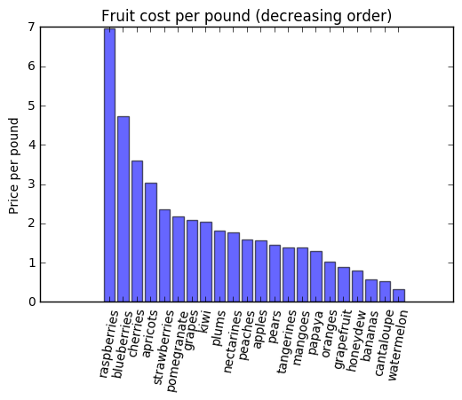

```python
fruit_sorted = fruit_only.sort_values(by='price_per_lb', ascending = False).ix[:,[1,3]]

fruit_lbl = list(fruit_sorted.ix[:,0])
indexes = np.arange(len(fruit_sorted))
prices = list(fruit_sorted.ix[:,1])

plt.bar(indexes, prices, align = 'center', alpha = 0.6)
plt.xticks(indexes, fruit_lbl, rotation=80)
plt.ylabel('Price per pound')
plt.title('Fruit cost per pound (decreasing order)')

plt.show()
```

Listed above are the top 5 most expensive and top 5 least expensive fruits. In my opinion, tables do the best job at capturing this data. However, I also plotted all fruits in the above plot to get a sense of how much more the most expensive fruits are compared to the rest. Rarer, smaller fruits and berries tend to be on the higher side, while larger and more common fruits are on the lower side.

**How do the price distributions compare for fruit and vegetables?**

```python
fv_df = pd.concat([fruit_df, veg_df], axis = 0, join = 'inner', ignore_index = True)
fruit_only = fv_df.loc[fv_df['type'] == "fruit"]
veg_only = fv_df.loc[fv_df['type'] == "vegetables"]
```

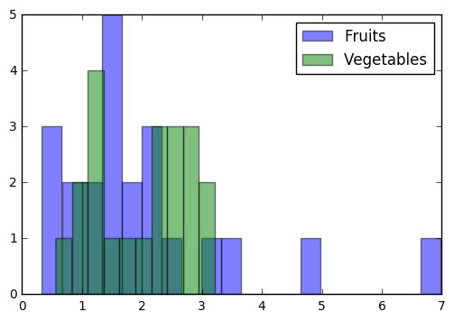

```python
plt.hist(fruit_only['price_per_lb'], bins = 20, alpha = 0.5, label = 'Fruits')
plt.hist(veg_only['price_per_lb'], bins = 10, alpha = 0.5, label='Vegetables')
plt.legend()
plt.show()
```

The means of the price per pound for vegetable group is slightly higher than for fruit, but the variance for the fruit group is much higher in comparison (there are some extreme deviations from the mean). The histograms of this phenomenon are shown above. With more data, the coalescing skewed right normal of the fruit group would be better shown (or debunked), and the distribution of the vegetable group may appear more normal than it looks here. The small sample sizes limit the conclusions we can draw.

**Which foods are the best value for the price?**

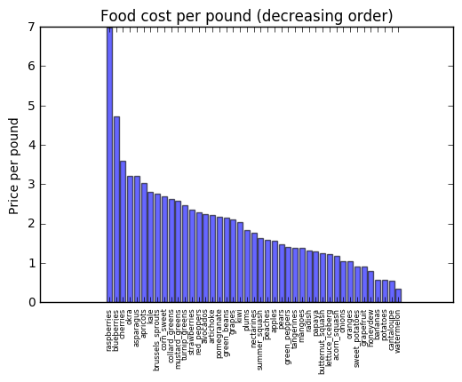

```python
all_sorted_lb = fv_df.sort_values(by='price_per_lb', ascending = False)

lbls_1 = list(all_sorted_lb.ix[:,1])
indexes_lb = np.arange(len(all_sorted_lb))
prices_lb = list(all_sorted_lb.ix[:,3])

plt.bar(indexes_lb, prices_lb, align = 'center', alpha = 0.6)
plt.xticks(indexes_lb, lbls_1, rotation=90, fontsize = 6)
plt.ylabel('Price per pound')
plt.title('Food cost per pound (decreasing order)')

plt.show()
```

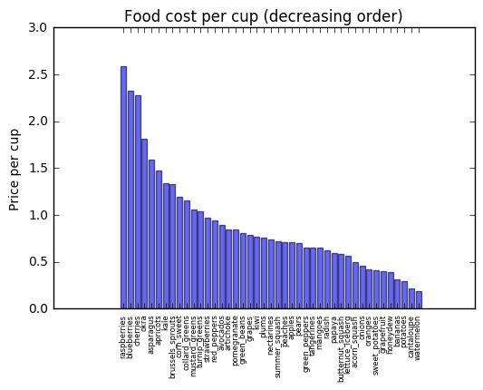

```python
all_sorted_cup = fv_df.sort_values(by='price_per_cup', ascending = False)

lbls_2 = list(all_sorted_lb.ix[:,1])
indexes_cup = np.arange(len(all_sorted_cup))
prices_cup = list(all_sorted_cup.ix[:,6])

plt.bar(indexes_cup, prices_cup, align = 'center', alpha = 0.6)
plt.xticks(indexes_cup, lbls_2, rotation=90, fontsize = 6)
plt.ylabel('Price per cup')
plt.title('Food cost per cup (decreasing order)')

plt.show()
```

**What's something surprising about this data set?**

A surprising detail about the data that we were able to read in (we are missing quite a bit of information, especially in the vegetables category) is the fact that the association between price per pound and yield is mildly positive for the fruits, but rather non-existent for the vegetables. A simple regression analysis would suffice in seeing if this relationship is significant in the fruits. More data would help in seeing if the difference between fruits and vegetables in this manner is actually legitimate. Time permitting, I would certainly examine this relationship to a greater extent, and learn more about how I can analyze this with regression techniques in Python.

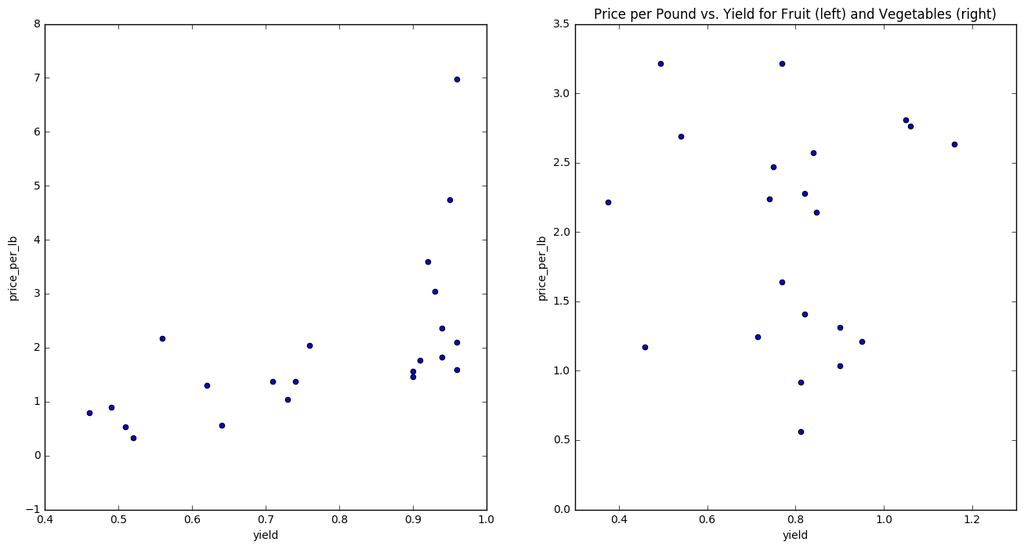

```python
fruit_only = fv_df.loc[fv_df['type'] == "fruit"]
veg_only = fv_df.loc[fv_df['type'] == "vegetables"]

fig, axs = plt.subplots(1, 2, sharey=False)
plt.title("Price per Pound vs. Yield for Fruit (left) and Vegetables (right)")
fruit_only.plot(kind='scatter', x='yield', y='price_per_lb', ax=axs[0], figsize=(16, 8))
veg_only.plot(kind='scatter', x='yield', y='price_per_lb', ax=axs[1])

plt.show()
```

**Which foods do you expect to provide the best combination of price, yield, and nutrition? A future assignment may combine this data set with another so you can check your hypothesis.**

Assuming we are considering only fruits and vegetables, a weighted model of price, yield, and a certain measure of nurtition (unknown at this time) will likely reveal that foods in the second quartile in terms of price per pound, third quartile in terms of yield, and are moderately to highly nutritious (categorical?) will be considered the best foods for the combination. Of course this depends on how the model is weighted. Hopefully, more details are to come with additional data and guidelines.